# Part iiiD2: Comparing tuned classification models

INFSCI 2595 Final

Ben Stein

4/27/2022

# About this document

In this document, I compare the performance of all tuned classification models in order to identify the one that seems the best.

# Setup

## Libraries and tools

```r
library(tidyverse)
library(caret)
source("./tools.R")
```

# Model performance

## ROC/Sensitivity/specificity

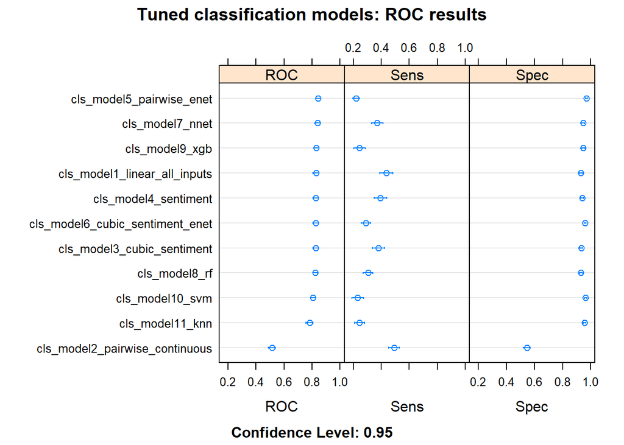

```r
all_cls_models_roc <- list(
  cls_model1_linear_all_inputs = load_model("adv_class_model1.rds"),
  cls_model2_pairwise_continuous = load_model("adv_class_model2.rds"),
  cls_model3_cubic_sentiment = load_model("adv_class_model3_cubic_sentiment.rds"),
  cls_model4_sentiment = load_model("adv_class_model4_continuous_linear.rds"),
  cls_model5_pairwise_enet = load_model("adv_class_model5_pairwise_continuous_linear_enet.rds"),
  cls_model6_cubic_sentiment_enet = load_model("adv_class_model6_cubic_sentiment_enet.rds"),
  cls_model7_nnet = load_model("adv_class_model7_nnet.rds"),
  cls_model8_rf = load_model("adv_class_model8_rf.rds"),
  cls_model9_xgb = load_model("adv_class_model9_xgb.rds"),
  cls_model10_svm = load_model("adv_class_model10_svm_rbf.rds"),
  cls_model11_knn = load_model("adv_class_model11_knn.rds")
)


dotplot(resamples(all_cls_models_roc), main = "Tuned classification models: ROC results")
```

## Accuracy

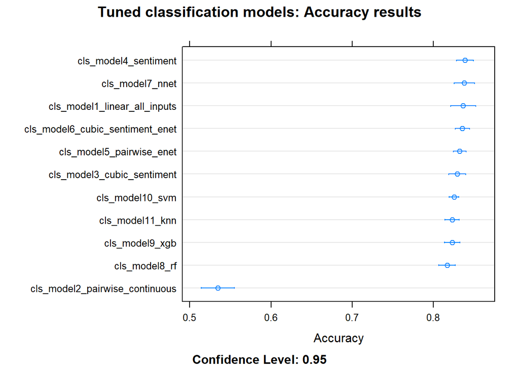

```r
all_cls_models_acc <- list(
  cls_model1_linear_all_inputs = load_model("adv_class_model1_acc.rds"),
  cls_model2_pairwise_continuous = load_model("adv_class_model2_acc.rds"),
  cls_model3_cubic_sentiment = load_model("adv_class_model3_cubic_sentiment_acc.rds"),
  cls_model4_sentiment = load_model("adv_class_model4_continuous_linear_acc.rds"),
  cls_model5_pairwise_enet = load_model("adv_class_model5_pairwise_continuous_linear_enet_acc.rds"),
  cls_model6_cubic_sentiment_enet = load_model("adv_class_model6_cubic_sentiment_enet_acc.rds"),
  cls_model7_nnet = load_model("adv_class_model7_nnet_acc.rds"),
  cls_model8_rf = load_model("adv_class_model8_rf_acc.rds"),
  cls_model9_xgb = load_model("adv_class_model9_xgb_acc.rds"),
  cls_model10_svm = load_model("adv_class_model10_svm_rbf_acc.rds"),
  cls_model11_knn = load_model("adv_class_model11_knn_acc.rds")
)

all_cls_models_acc_results <- resamples(all_cls_models_acc)
dotplot(all_cls_models_acc_results, main = "Tuned classification models: Accuracy results", metric = "Accuracy")
```

Across all resamplings, the accuracy for the top, say, 6 models is *very* close. Not much help.

## Kappa

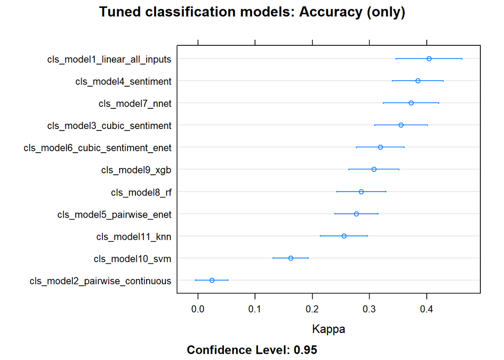

```r
dotplot(all_cls_models_acc_results, main = "Tuned classification models: Accuracy (only)", metric = "Kappa")
```

There is more separation here, but this is still a bit concerning. These are relatively low values of kappa as I understand the term. I suspect the strong accuracy juxtaposed against relatively weaker kappa is related to the imbalance of the dataset (because there are significantly more non-events than events.)

However, we have to move on, so I’ll say that the winner so far seems to model 4 (though all are close). It has a good balance of ROC, sensitivity, accuracy, and Kappa.

## AIC

Out of curiosity, let’s look at the AIC of leading models to help us decide. I can’t find a generalized version of AIC that works for neural nets, but we can do the other three, I guess.

```r
leading_cls_models <- list(
  cls_model1 = all_cls_models_roc$cls_model1_linear_all_inputs$finalModel,
  cls_model3 = all_cls_models_roc$cls_model3_cubic_sentiment$finalModel,
  cls_model4 = all_cls_models_roc$cls_model4_sentiment$finalModel
)

leading_cls_models %>% purrr::map(AIC)
```

```
## $cls_model1
## [1] 488.7758
##
## $cls_model3
## [1] 492.3602
##
## $cls_model4
## [1] 496.4571
```

These are all quite close to one another, though I’m not sure if there good in an absolute sense, and I don’t know how to compare them to the neural net. Model 4’s higher AIC may suggest that we should be picking model 1. I’m not sure. I’m choosing **model 4** because I think it’ll provide more interesting analysis based on its formulation (model 1 is just all predictors in linear combination).